# STAT 545A - Assignment 4

Sean La

08/10/2019

# Exercise 1

## Univariate Option 1

We’ll work with the `gapminder` dataset for this exercise. We’ll take the life expectancies of France, Germany, and Austria.

```r
# This tibble will contain the life expectancies. It will be quite wide.
(wide_life_exp_tbl <- gapminder %>%
  filter(country %in% c('France','Germany','Austria')) %>% # Select France, Germany, and Austria
  select(country, year, lifeExp) %>% # Select only the columns 'country', 'year', and 'lifeExp', since we don't need the other columns.
  pivot_wider(id_cols = year,        # Pivot the table to make it wider, each column corresponding to a country, and the entries below the columns
              names_from = country,  # being the life expectancies for each year.
              values_from = lifeExp))
```

| year | Austria | France | Germany |
| --- | --- | --- | --- |
| 1952 | 66.800 | 67.410 | 67.500 |
| 1957 | 67.480 | 68.930 | 69.100 |
| 1962 | 69.540 | 70.510 | 70.300 |
| 1967 | 70.140 | 71.550 | 70.800 |
| 1972 | 70.630 | 72.380 | 71.000 |
| 1977 | 72.170 | 73.830 | 72.500 |
| 1982 | 73.180 | 74.890 | 73.800 |
| 1987 | 74.940 | 76.340 | 74.847 |
| 1992 | 76.040 | 77.460 | 76.070 |
| 1997 | 77.510 | 78.640 | 77.340 |

[output cut: 2 more lines]

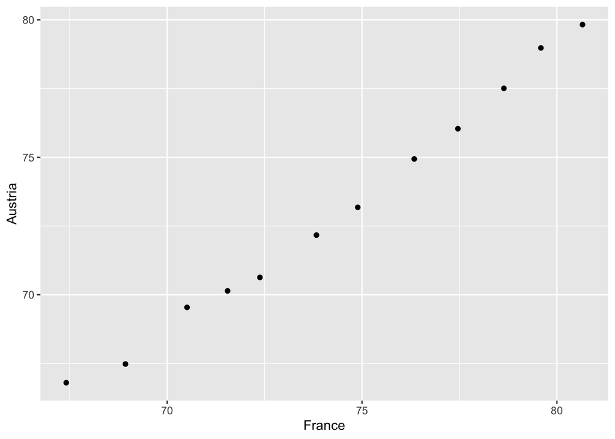

```r
wide_life_exp_tbl %>%
  ggplot(aes(x=France,y=Austria)) + # Compare the life expectancies between France and Austria
  geom_point() # Scatterplot it
```

Each point in the above plot corresponds to every fifth year between 1952 to 2007 inclusive. The x-value of the point is the life expectancy of France in that year, and the y-value is the life expectancy of Austria. The points lie roughly on the line $y=x$, which implies that Austria and France have had similar life expectancies from 1952 to 2007. As well, because the points lie on the line $y = x$, this also implies that Austria and France have had similar changes in life expectancy from 1952 to 2007.

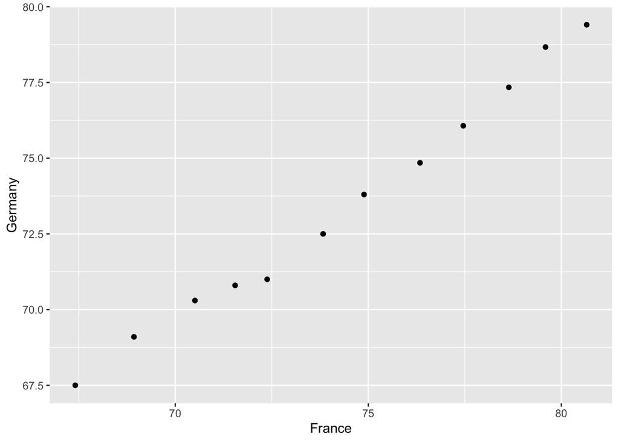

```r
wide_life_exp_tbl %>%
  ggplot(aes(x=France, y=Germany)) + # Compare the life expectancies between France and Germany
  geom_point() # Scatterplot it
```

Let’s now reshape the tibble to be in long format again.

```r
(long_life_exp_tbl <- wide_life_exp_tbl %>%
  pivot_longer(cols = c('Austria', 'Germany', 'France'),
               names_to = 'country',
               values_to = 'lifeExp'))
```

| year | country | lifeExp |
| --- | --- | --- |
| 1952 | Austria | 66.800 |
| 1952 | Germany | 67.500 |
| 1952 | France | 67.410 |
| 1957 | Austria | 67.480 |
| 1957 | Germany | 69.100 |
| 1957 | France | 68.930 |
| 1962 | Austria | 69.540 |
| 1962 | Germany | 70.300 |
| 1962 | France | 70.510 |
| 1967 | Austria | 70.140 |

[output cut: 26 more lines]

Good as new!

# Exercise 2

## Multivariate option 2

Let’s make a wide tibble where each row is year, and the columns are life expectancy and GDP per capita for Iceland and Denmark.

```r
(wide_multivariate_tbl <- gapminder %>%
  select(year, country, lifeExp, gdpPercap) %>% # Select the year, country, life expectancy, and GDP per capita columns.
  filter(country %in% c('Iceland', 'Denmark')) %>%
  pivot_wider(id_cols = year,
              names_from = country,
              names_sep = '_',
              values_from = c(lifeExp, gdpPercap)))
```

| year | lifeExp_Denmark | lifeExp_Iceland | gdpPercap_Denmark | gdpPercap_Iceland |
| --- | --- | --- | --- | --- |
| 1952 | 70.780 | 72.490 | 9692.385 | 7267.688 |
| 1957 | 71.810 | 73.470 | 11099.659 | 9244.001 |
| 1962 | 72.350 | 73.680 | 13583.314 | 10350.159 |
| 1967 | 72.960 | 73.730 | 15937.211 | 13319.896 |
| 1972 | 73.470 | 74.460 | 18866.207 | 15798.064 |
| 1977 | 74.690 | 76.110 | 20422.901 | 19654.962 |
| 1982 | 74.630 | 76.990 | 21688.040 | 23269.607 |
| 1987 | 74.800 | 77.230 | 25116.176 | 26923.206 |
| 1992 | 75.330 | 78.770 | 26406.740 | 25144.392 |
| 1997 | 76.110 | 78.950 | 29804.346 | 28061.100 |

[output cut: 2 more lines]

Now each column corresponds to the life expectancy or GDP per capita for either Denmark or Iceland.

Let’s make the tibble longer again, using science!

```r
wide_multivariate_tbl %>%
  pivot_longer(cols = -year,
               names_to = c('.value','country'),
               names_sep = '_')
```

| year | country | lifeExp | gdpPercap |
| --- | --- | --- | --- |
| 1952 | Denmark | 70.780 | 9692.385 |
| 1952 | Iceland | 72.490 | 7267.688 |
| 1957 | Denmark | 71.810 | 11099.659 |
| 1957 | Iceland | 73.470 | 9244.001 |
| 1962 | Denmark | 72.350 | 13583.314 |
| 1962 | Iceland | 73.680 | 10350.159 |
| 1967 | Denmark | 72.960 | 15937.211 |
| 1967 | Iceland | 73.730 | 13319.896 |
| 1972 | Denmark | 73.470 | 18866.207 |
| 1972 | Iceland | 74.460 | 15798.064 |

[output cut: 14 more lines]

We’ve successfully converted the four columns for life expectancy and GDP per capita for Iceland and Denmark into three columns.

# Exercise 3

Let’s download the data for this exercise.

```r
guest <- read_csv("https://raw.githubusercontent.com/STAT545-UBC/Classroom/master/data/wedding/attend.csv")
email <- read_csv("https://raw.githubusercontent.com/STAT545-UBC/Classroom/master/data/wedding/emails.csv")
```

The `guest` dataset looks like this:

```r
guest
```

| party | name | meal_wedding | meal_brunch | attendance_wedding | attendance_brunch | attendance_golf |
| --- | --- | --- | --- | --- | --- | --- |
| 1 | Sommer Medrano | PENDING | PENDING | PENDING | PENDING | PENDING |
| 1 | Phillip Medrano | vegetarian | Menu C | CONFIRMED | CONFIRMED | CONFIRMED |
| 1 | Blanka Medrano | chicken | Menu A | CONFIRMED | CONFIRMED | CONFIRMED |
| 1 | Emaan Medrano | PENDING | PENDING | PENDING | PENDING | PENDING |
| 2 | Blair Park | chicken | Menu C | CONFIRMED | CONFIRMED | CONFIRMED |
| 2 | Nigel Webb | NA | NA | CANCELLED | CANCELLED | CANCELLED |
| 3 | Sinead English | PENDING | PENDING | PENDING | PENDING | PENDING |
| 4 | Ayra Marks | vegetarian | Menu B | PENDING | PENDING | PENDING |
| 5 | Atlanta Connolly | PENDING | PENDING | PENDING | PENDING | PENDING |
| 5 | Denzel Connolly | fish | Menu B | CONFIRMED | CONFIRMED | CONFIRMED |

[output cut: 20 more lines]

The `email` dataset looks like so:

```r
email
```

| guest | email |
| --- | --- |
| Sommer Medrano, Phillip Medrano, Blanka Medrano, Emaan Medrano | sommm@gmail.com |
| Blair Park, Nigel Webb | bpark@gmail.com |
| Sinead English | singlish@hotmail.ca |
| Ayra Marks | marksa42@gmail.com |
| Jolene Welsh, Hayley Booker | jw1987@hotmail.com |
| Amayah Sanford, Erika Foley | erikaaaaaa@gmail.com |
| Ciaron Acosta | shining_ciaron@gmail.com |
| Diana Stuart | doodledianastu@gmail.com |
| Daisy-May Caldwell, Martin Caldwell, Violet Caldwell, Nazifa Caldwell, Eric Caldwell | caldwellfamily5212@gmail.com |
| Rosanna Bird, Kurtis Frost | rosy1987b@gmail.com |

[output cut: 4 more lines]

The `email` dataset is kind of inconvenient at the moment in that several guests are grouped in the same row. Let’s make a row for each unique guest.

```r
# `sep = ', '` indicates that guest names are separated by a comma, followed by a space
(email <- email %>% separate_rows(guest, sep = ', '))
```

| guest | email |
| --- | --- |
| Sommer Medrano | sommm@gmail.com |
| Phillip Medrano | sommm@gmail.com |
| Blanka Medrano | sommm@gmail.com |
| Emaan Medrano | sommm@gmail.com |
| Blair Park | bpark@gmail.com |
| Nigel Webb | bpark@gmail.com |
| Sinead English | singlish@hotmail.ca |
| Ayra Marks | marksa42@gmail.com |
| Jolene Welsh | jw1987@hotmail.com |
| Hayley Booker | jw1987@hotmail.com |

[output cut: 18 more lines]

That’s better! Let’s now work with the datasets.

## Exercise 3.1

Let’s add a column corresponding to the email for each guest.

```r
left_join(guest, email, by=c("name" = "guest"))
```

| party | name | meal_wedding | meal_brunch | attendance_wedding | attendance_brunch | attendance_golf | email |
| --- | --- | --- | --- | --- | --- | --- | --- |
| 1 | Sommer Medrano | PENDING | PENDING | PENDING | PENDING | PENDING | sommm@gmail.com |
| 1 | Phillip Medrano | vegetarian | Menu C | CONFIRMED | CONFIRMED | CONFIRMED | sommm@gmail.com |
| 1 | Blanka Medrano | chicken | Menu A | CONFIRMED | CONFIRMED | CONFIRMED | sommm@gmail.com |
| 1 | Emaan Medrano | PENDING | PENDING | PENDING | PENDING | PENDING | sommm@gmail.com |
| 2 | Blair Park | chicken | Menu C | CONFIRMED | CONFIRMED | CONFIRMED | bpark@gmail.com |
| 2 | Nigel Webb | NA | NA | CANCELLED | CANCELLED | CANCELLED | bpark@gmail.com |
| 3 | Sinead English | PENDING | PENDING | PENDING | PENDING | PENDING | singlish@hotmail.ca |
| 4 | Ayra Marks | vegetarian | Menu B | PENDING | PENDING | PENDING | marksa42@gmail.com |
| 5 | Atlanta Connolly | PENDING | PENDING | PENDING | PENDING | PENDING | NA |
| 5 | Denzel Connolly | fish | Menu B | CONFIRMED | CONFIRMED | CONFIRMED | NA |

[output cut: 20 more lines]

Each guest is paired with an email now.

## Exercise 3.2

Let’s find out people who we have emails for, but are not on the guestlist.

```r
anti_join(email, guest, by=c('guest' = 'name'))
```

| guest | email |
| --- | --- |
| Turner Jones | tjjones12@hotmail.ca |
| Albert Marshall | themarshallfamily1234@gmail.com |
| Vivian Marshall | themarshallfamily1234@gmail.com |

Turner, Albert, and Vivian are not invited to the wedding! This will make for some juicy gossip at the next country club meeting.

## Exercise 3.3

Ah, I forgot we’re not in high school anymore, so we should put everyone in `email` on the guest list to avoid drama.

```r
complete_guestlist <- full_join(guest, email, by = c('name' = 'guest'))
```

Let’s confirm that Turner, Albert, and Vivian are indeed on the guestlist now.

```r
complete_guestlist %>% filter(name %in% c('Turner Jones', 'Albert Marshall', 'Vivian Marshall'))
```

| party | name | meal_wedding | meal_brunch | attendance_wedding | attendance_brunch | attendance_golf | email |
| --- | --- | --- | --- | --- | --- | --- | --- |
| NA | Turner Jones | NA | NA | NA | NA | NA | tjjones12@hotmail.ca |
| NA | Albert Marshall | NA | NA | NA | NA | NA | themarshallfamily1234@gmail.com |
| NA | Vivian Marshall | NA | NA | NA | NA | NA | themarshallfamily1234@gmail.com |

They’re on the list now! Perfect.